# Study Questions: On interpreting parameters in dynamic panel models

Manuel Voelkle

2025-07-02

## 1. The fundamental problem of causal inference

**Question:**  
Explain in your own words: What is *the fundamental problem of causal inference*? How can we deal with it?

**Sample Solution**

The fundamental problem of causal inference is that we can never directly observe a causal effect for a single individual. To know whether a treatment or exposure caused an outcome, we would need to observe what would have happened to the same person at the same time both with and without the treatment. But this is impossible—we only ever observe one of these two potential outcomes. This dilemma is also known as the counterfactual problem.

Since we can’t directly observe counterfactuals, we try to approximate them using research designs and statistical controls, such as:

*Randomized Experiments:* By randomly assigning units to treatment and control groups, we assume that, on average, the only difference between the groups is the treatment. This allows us to estimate the average treatment effect by comparing group outcomes.

*Longitudinal Observational Models:* When experiments aren’t feasible, we can resort to alternatives such as dynamic panel models to simulate experimental control by adjusting for prior states, controlling for unobserved stable differences, accounting for co-movement, and factoring in occasion-specific effects. If the adjustment works, these models allow us to make conditional causal inferences, often referred to as Granger-type causality—meaning we infer that one variable predicts future changes in another, beyond what past values of that variable alone can explain. By doing so, we can *infer* causal effects, even though we can’t directly observe them

## 2. Major threats to causal inference in longitudinal models

**Question:**  
List and describe four major problems with the “scientific solution” to causal inference discussed in class.

**Sample Solution**

1. Occasion effects – External events that affect all observations at a specific time (e.g., economic crisis).
2. Autoregressive effects – The influence of prior states of a variable on its future state.
3. Co-movement – Simultaneous changes in variables due to a shared cause (e.g., income and well-being rising due to policy change).
4. Unit heterogeneity – Stable between-person differences that confound relationships (e.g., personality traits).

If unaddressed, these factors can bias parameter estimates. Dynamic panel models handle them by incorporating appropriate controls like occasion specific intercepts, lagged effects, correlated residuals, or random intercepts.

## 3. Extensions beyond basic discrete time random intercept cross lagged panel models

**Question:**  
Describe at least two extensions to standard discrete time random intercept cross-lagged panel models that improve their realism for modeling psychological processes.

**Sample Solution**

To better reflect complex real-world dynamics, the basic mdel can be extended with:

1. Moving Average (MA) Effects: Model how past residuals (e.g., shocks or errors) continue to influence future outcomes.
2. Cross-Lagged MA (CLMA) Effects: Capture delayed effects across variables, allowing a past shock in X to affect Y directly and indirectly over time.
3. Higher-Order Lags (e.g., AR(2), CL(2)): Reflect that effects might not be immediate but spread across multiple time lags.

These extensions increase model flexibility and are especially useful in studying more complex reciprocal relationships

## 4. Interpretation of higher order AR effects

**Question:**  
Below is a plot showing a simulated autoregressive process of order 2 (AR(2)):

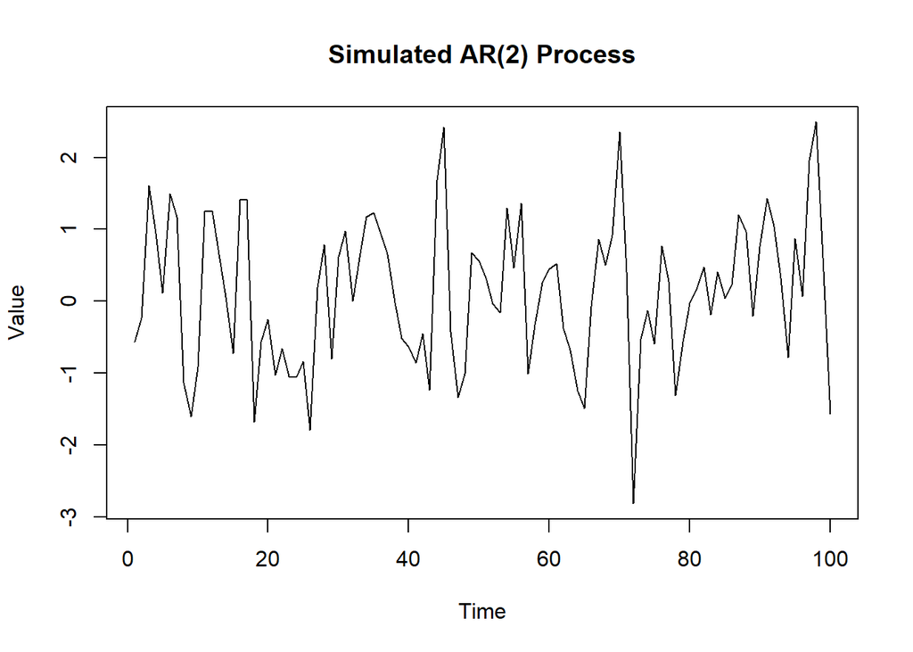

Simulated AR(2) process with ϕ₁ = 0.5, ϕ₂ = -0.3

1. Describe in your own words how an AR(2) process differs from an AR(1) process in terms of temporal dynamics.
2. What do the coefficients $ϕ_1 = 0.5$ and $ϕ_2 = -0.3$ suggest about the memory and oscillation of the process?

**Sample Solution**

**a)** An AR(2) process includes both the previous value ($y_{t-1}$) and the value two steps back ($y_{t-2}$), which allows for more complex dynamics such as dampened oscillations or delayed responses. In contrast, AR(1) only accounts for immediate past values, leading to smoother decay.